# Import Libraries

```python
import numpy as np
import pandas as pd
import os
import matplotlib.pyplot as plt
import warnings
warnings.filterwarnings('ignore')
from matplotlib.pylab import rcParams
rcParams['figure.figsize'] = 15, 6
```

# Load Data Set

Reads a CSV file containing stock price data

```python
os.chdir ('C:\\Users\\DELL\\Documents\\ML with Python - Acmegrade')
```

```python
df =pd.read_csv("prices.csv", header=0)
display (df)
```

|  | date | symbol | open | close | low | high | volume |
| --- | --- | --- | --- | --- | --- | --- | --- |
| 0 | 2016-01-05 00:00:00 | WLTW | 123.430000 | 125.839996 | 122.309998 | 126.250000 | 2163600.0 |
| 1 | 2016-01-06 00:00:00 | WLTW | 125.239998 | 119.980003 | 119.940002 | 125.540001 | 2386400.0 |
| 2 | 2016-01-07 00:00:00 | WLTW | 116.379997 | 114.949997 | 114.930000 | 119.739998 | 2489500.0 |
| 3 | 2016-01-08 00:00:00 | WLTW | 115.480003 | 116.620003 | 113.500000 | 117.440002 | 2006300.0 |
| 4 | 2016-01-11 00:00:00 | WLTW | 117.010002 | 114.970001 | 114.089996 | 117.330002 | 1408600.0 |
| ... | ... | ... | ... | ... | ... | ... | ... |
| 851259 | 2016-12-30 | ZBH | 103.309998 | 103.199997 | 102.849998 | 103.930000 | 973800.0 |
| 851260 | 2016-12-30 | ZION | 43.070000 | 43.040001 | 42.689999 | 43.310001 | 1938100.0 |
| 851261 | 2016-12-30 | ZTS | 53.639999 | 53.529999 | 53.270000 | 53.740002 | 1701200.0 |
| 851262 | 2016-12-30 00:00:00 | AIV | 44.730000 | 45.450001 | 44.410000 | 45.590000 | 1380900.0 |
| 851263 | 2016-12-30 00:00:00 | FTV | 54.200001 | 53.630001 | 53.389999 | 54.480000 | 705100.0 |

851264 rows × 7 columns

# Data Preprocessing

```python
# Display the shape
print(df.shape)
```

```
(851264, 7)
```

```python
# Display the column names
print(df.columns)
```

```
Index(['date', 'symbol', 'open', 'close', 'low', 'high', 'volume'], dtype='object')
```

```python
# Value count (Number of records by company)
df.symbol.value_counts()
```

```
KSU     1762
NOC     1762
ORCL    1762
OMC     1762
OKE     1762
        ...
KHC      378
HPE      304
CSRA     284
WLTW     251
FTV      126
Name: symbol, Length: 501, dtype: int64
```

```python
# Unique Values
df.symbol.unique()
```

```
array(['WLTW', 'A', 'AAL', 'AAP', 'AAPL', 'ABC', 'ABT', 'ACN', 'ADBE',
       'ADI', 'ADM', 'ADP', 'ADS', 'ADSK', 'AEE', 'AEP', 'AES', 'AET',
       'AFL', 'AGN', 'AIG', 'AIZ', 'AJG', 'AKAM', 'ALB', 'ALK', 'ALL',
       'ALXN', 'AMAT', 'AME', 'AMG', 'AMGN', 'AMP', 'AMT', 'AMZN', 'AN',
       'ANTM', 'AON', 'APA', 'APC', 'APD', 'APH', 'ARNC', 'ATVI', 'AVB',
       'AVGO', 'AVY', 'AWK', 'AXP', 'AYI', 'AZO', 'BA', 'BAC', 'BAX',
       'BBBY', 'BBT', 'BBY', 'BCR', 'BDX', 'BEN', 'BHI', 'BIIB', 'BK',
       'BLK', 'BLL', 'BMY', 'BSX', 'BWA', 'BXP', 'C', 'CA', 'CAG', 'CAH',
       'CAT', 'CB', 'CBG', 'CBS', 'CCI', 'CCL', 'CELG', 'CERN', 'CF',
       'CHD', 'CHK', 'CHRW', 'CI', 'CINF', 'CL', 'CLX', 'CMA', 'CMCSA',
       'CME', 'CMG', 'CMI', 'CMS', 'CNC', 'CNP', 'COF', 'COG', 'COH',
       'COL', 'COO', 'COP', 'COST', 'CPB', 'CRM', 'CSCO', 'CSX', 'CTAS',
       'CTL', 'CTSH', 'CTXS', 'CVS', 'CVX', 'CXO', 'D', 'DAL', 'DD', 'DE',
       'DFS', 'DG', 'DGX', 'DHI', 'DHR', 'DIS', 'DISCA', 'DISCK', 'DLR',
       'DLTR', 'DNB', 'DOV', 'DOW', 'DPS', 'DRI', 'DTE', 'DUK', 'DVA',
       'DVN', 'EA', 'EBAY', 'ECL', 'ED', 'EFX', 'EIX', 'EL', 'EMN', 'EMR',
       'ENDP', 'EOG', 'EQIX', 'EQR', 'EQT', 'ES', 'ESRX', 'ESS', 'ETFC',
       'ETN', 'ETR', 'EW', 'EXC', 'EXPD', 'EXPE', 'EXR', 'F', 'FAST',
       'FCX', 'FDX', 'FE', 'FFIV', 'FIS', 'FISV', 'FITB', 'FL', 'FLIR',
       'FLR', 'FLS', 'FMC', 'FOX', 'FOXA', 'FRT', 'FSLR', 'FTI', 'FTR',
       'GD', 'GE', 'GGP', 'GILD', 'GIS', 'GLW', 'GOOG', 'GOOGL', 'GPC',
       'GPN', 'GPS', 'GRMN', 'GS', 'GT', 'GWW', 'HAL', 'HAR', 'HAS',
       'HBAN', 'HBI', 'HCN', 'HCP', 'HD', 'HES', 'HIG', 'HOG', 'HOLX',
       'HON', 'HP', 'HPQ', 'HRB', 'HRL', 'HRS', 'HSIC', 'HST', 'HSY',
       'HUM', 'IBM', 'ICE', 'IDXX', 'IFF', 'ILMN', 'INTC', 'INTU', 'IP',
       'IPG', 'IR', 'IRM', 'ISRG', 'ITW', 'IVZ', 'JBHT', 'JCI', 'JEC',
       'JNJ', 'JNPR', 'JPM', 'JWN', 'K', 'KEY', 'KIM', 'KLAC', 'KMB',
       'KMX', 'KO', 'KR', 'KSS', 'KSU', 'L', 'LB', 'LEG', 'LEN', 'LH',
       'LKQ', 'LLL', 'LLTC', 'LLY', 'LMT', 'LNC', 'LNT', 'LOW', 'LRCX',
       'LUK', 'LUV', 'LVLT', 'M', 'MA', 'MAA', 'MAC', 'MAR', 'MAS', 'MAT',
       'MCD', 'MCHP', 'MCK', 'MCO', 'MDLZ', 'MDT', 'MET', 'MHK', 'MJN',
       'MKC', 'MLM', 'MMC', 'MMM', 'MNST', 'MO', 'MON', 'MOS', 'MRK',
       'MRO', 'MSFT', 'MSI', 'MTB', 'MTD', 'MU', 'MUR', 'MYL', 'NBL',
       'NDAQ', 'NEE', 'NEM', 'NFLX', 'NFX', 'NI', 'NKE', 'NOC', 'NOV',
       'NRG', 'NSC', 'NTAP', 'NTRS', 'NUE', 'NVDA', 'NWL', 'O', 'OKE',
       'OMC', 'ORCL', 'ORLY', 'OXY', 'PAYX', 'PBCT', 'PBI', 'PCAR', 'PCG',
       'PCLN', 'PDCO', 'PEG', 'PEP', 'PFE', 'PFG', 'PG', 'PGR', 'PH',
       'PHM', 'PKI', 'PLD', 'PM', 'PNC', 'PNR', 'PNW', 'PPG', 'PPL',
       'PRGO', 'PRU', 'PSA', 'PVH', 'PWR', 'PX', 'PXD', 'QCOM', 'R',
       'RAI', 'RCL', 'REGN', 'RF', 'RHI', 'RHT', 'RIG', 'RL', 'ROK',
       'ROP', 'ROST', 'RRC', 'RSG', 'RTN', 'SBUX', 'SCG', 'SCHW', 'SE',
       'SEE', 'SHW', 'SIG', 'SJM', 'SLB', 'SLG', 'SNA', 'SNI', 'SO',
       'SPG', 'SPGI', 'SPLS', 'SRCL', 'SRE', 'STI', 'STT', 'STX', 'STZ',
       'SWK', 'SWKS', 'SWN', 'SYK', 'SYMC', 'SYY', 'T', 'TAP', 'TDC',
       'TEL', 'TGNA', 'TGT', 'TIF', 'TJX', 'TMK', 'TMO', 'TROW', 'TRV',
       'TSCO', 'TSN', 'TSO', 'TSS', 'TWX', 'TXN', 'TXT', 'UAA', 'UAL',
       'UDR', 'UHS', 'ULTA', 'UNH', 'UNM', 'UNP', 'UPS', 'URBN', 'URI',
       'USB', 'UTX', 'V', 'VAR', 'VFC', 'VIAB', 'VLO', 'VMC', 'VNO',
       'VRSK', 'VRSN', 'VRTX', 'VTR', 'VZ', 'WAT', 'WBA', 'WDC', 'WEC',
       'WFC', 'WFM', 'WHR', 'WM', 'WMB', 'WMT', 'WU', 'WY', 'WYN', 'WYNN',
       'XEC', 'XEL', 'XL', 'XLNX', 'XOM', 'XRAY', 'XRX', 'YHOO', 'YUM',
       'ZBH', 'ZION', 'AIV', 'CHTR', 'LYB', 'GM', 'ABBV', 'DLPH', 'FB',
       'FBHS', 'HCA', 'KMI', 'KORS', 'MPC', 'NLSN', 'PSX', 'TDG', 'TRIP',
       'XYL', 'ZTS', 'COTY', 'MNK', 'NWS', 'NWSA', 'EVHC', 'ALLE', 'CFG',
       'NAVI', 'QRVO', 'SYF', 'WRK', 'KHC', 'PYPL', 'HPE', 'CSRA', 'FTV'],
      dtype=object)
```

```python
# Number of Unique Values
display(df.symbol.unique().shape)
```

```
(501,)
```

```python
# First 20 Unique values
df.symbol.unique()[0:20]
```

```
array(['WLTW', 'A', 'AAL', 'AAP', 'AAPL', 'ABC', 'ABT', 'ACN', 'ADBE',
       'ADI', 'ADM', 'ADP', 'ADS', 'ADSK', 'AEE', 'AEP', 'AES', 'AET',
       'AFL', 'AGN'], dtype=object)
```

```python
# Number of Records
print(len(df.symbol.values))
```

```
851264
```

```python
# Display Info
df.info()
```

```
<class 'pandas.core.frame.DataFrame'>
RangeIndex: 851264 entries, 0 to 851263
Data columns (total 7 columns):
 #   Column  Non-Null Count   Dtype
---  ------  --------------   -----
 0   date    851264 non-null  object
 1   symbol  851264 non-null  object
 2   open    851264 non-null  float64
 3   close   851264 non-null  float64
 4   low     851264 non-null  float64
 5   high    851264 non-null  float64
 6   volume  851264 non-null  float64
dtypes: float64(5), object(2)
memory usage: 45.5+ MB
```

```python
# Describe the column
# Gives the details of each column of the dataset like mean, max, etc
df.describe()
```

|  | open | close | low | high | volume |
| --- | --- | --- | --- | --- | --- |
| count | 851264.000000 | 851264.000000 | 851264.000000 | 851264.000000 | 8.512640e+05 |
| mean | 70.836986 | 70.857109 | 70.118414 | 71.543476 | 5.415113e+06 |
| std | 83.695876 | 83.689686 | 82.877294 | 84.465504 | 1.249468e+07 |
| min | 0.850000 | 0.860000 | 0.830000 | 0.880000 | 0.000000e+00 |
| 25% | 33.840000 | 33.849998 | 33.480000 | 34.189999 | 1.221500e+06 |
| 50% | 52.770000 | 52.799999 | 52.230000 | 53.310001 | 2.476250e+06 |
| 75% | 79.879997 | 79.889999 | 79.110001 | 80.610001 | 5.222500e+06 |
| max | 1584.439941 | 1578.130005 | 1549.939941 | 1600.930054 | 8.596434e+08 |

```python
# Check for NULL Values
# checking whether there is any null value in the dataset
# .sum() will give the total no. of null value column-wise
df.isnull().sum()
```

```
date      0
symbol    0
open      0
close     0
low       0
high      0
volume    0
dtype: int64
```

```python
# Get all Unique Dates
df.date.unique()
```

```
array(['2016-01-05 00:00:00', '2016-01-06 00:00:00',
       '2016-01-07 00:00:00', ..., '2016-12-28', '2016-12-29',
       '2016-12-30'], dtype=object)
```

```python
# Display Date as  Data Frame
pd.DataFrame(df.date.unique())
```

|  | 0 |
| --- | --- |
| 0 | 2016-01-05 00:00:00 |
| 1 | 2016-01-06 00:00:00 |
| 2 | 2016-01-07 00:00:00 |
| 3 | 2016-01-08 00:00:00 |
| 4 | 2016-01-11 00:00:00 |
| ... | ... |
| 3519 | 2016-12-23 |
| 3520 | 2016-12-27 |
| 3521 | 2016-12-28 |
| 3522 | 2016-12-29 |
| 3523 | 2016-12-30 |

3524 rows × 1 columns

```python
# Check for Duplicate Records
df.duplicated().sum()
```

```
0
```

# Load the File

Loads another CSV file containing company details

```python
#Calling the file named securities.csv, It has the company details
comp_info = pd.read_csv('securities.csv')
comp_info
```

|  | Ticker symbol | Security | SEC filings | GICS Sector | GICS Sub Industry | Address of Headquarters | Date first added | CIK |
| --- | --- | --- | --- | --- | --- | --- | --- | --- |
| 0 | MMM | 3M Company | reports | Industrials | Industrial Conglomerates | St. Paul, Minnesota | NaN | 66740 |
| 1 | ABT | Abbott Laboratories | reports | Health Care | Health Care Equipment | North Chicago, Illinois | 31-03-1964 | 1800 |
| 2 | ABBV | AbbVie | reports | Health Care | Pharmaceuticals | North Chicago, Illinois | 31-12-2012 | 1551152 |
| 3 | ACN | Accenture plc | reports | Information Technology | IT Consulting & Other Services | Dublin, Ireland | 06-07-2011 | 1467373 |
| 4 | ATVI | Activision Blizzard | reports | Information Technology | Home Entertainment Software | Santa Monica, California | 31-08-2015 | 718877 |
| ... | ... | ... | ... | ... | ... | ... | ... | ... |
| 500 | YHOO | Yahoo Inc. | reports | Information Technology | Internet Software & Services | Sunnyvale, California | NaN | 1011006 |
| 501 | YUM | Yum! Brands Inc | reports | Consumer Discretionary | Restaurants | Louisville, Kentucky | 06-10-1997 | 1041061 |
| 502 | ZBH | Zimmer Biomet Holdings | reports | Health Care | Health Care Equipment | Warsaw, Indiana | NaN | 1136869 |
| 503 | ZION | Zions Bancorp | reports | Financials | Regional Banks | Salt Lake City, Utah | NaN | 109380 |
| 504 | ZTS | Zoetis | reports | Health Care | Pharmaceuticals | Florham Park, New Jersey | 21-06-2013 | 1555280 |

505 rows × 8 columns

# Data Preprocessing

```python
# Check for Unique count
comp_info["Ticker symbol"].nunique()
```

```
505
```

```python
# Check for info
comp_info.info()
```

```
<class 'pandas.core.frame.DataFrame'>
RangeIndex: 505 entries, 0 to 504
Data columns (total 8 columns):
 #   Column                   Non-Null Count  Dtype
---  ------                   --------------  -----
 0   Ticker symbol            505 non-null    object
 1   Security                 505 non-null    object
 2   SEC filings              505 non-null    object
 3   GICS Sector              505 non-null    object
 4   GICS Sub Industry        505 non-null    object
 5   Address of Headquarters  505 non-null    object
 6   Date first added         307 non-null    object
 7   CIK                      505 non-null    int64
dtypes: int64(1), object(7)
memory usage: 31.7+ KB
```

```python
# Check for Null Values
comp_info.isnull().sum()
```

```
Ticker symbol                0
Security                     0
SEC filings                  0
GICS Sector                  0
GICS Sub Industry            0
Address of Headquarters      0
Date first added           198
CIK                          0
dtype: int64
```

```python
# Describe the Details
comp_info.describe()
```

|  | CIK |
| --- | --- |
| count | 5.050000e+02 |
| mean | 7.074490e+05 |
| std | 5.144375e+05 |
| min | 1.800000e+03 |
| 25% | 8.631200e+04 |
| 50% | 8.310010e+05 |
| 75% | 1.075531e+06 |
| max | 1.659166e+06 |

```python
# Search for Particular company details
# for locating specific data here.... in security column of string that starts with "Face"
comp_info.loc[comp_info.Security.str.startswith('Face') , :]
```

|  | Ticker symbol | Security | SEC filings | GICS Sector | GICS Sub Industry | Address of Headquarters | Date first added | CIK |
| --- | --- | --- | --- | --- | --- | --- | --- | --- |
| 181 | FB | Facebook | reports | Information Technology | Internet Software & Services | Menlo Park, California | 23-12-2013 | 1326801 |

```python
# Example – Search for another company - Acc
comp_info.loc[comp_info.Security.str.startswith('Acc') , :]
```

|  | Ticker symbol | Security | SEC filings | GICS Sector | GICS Sub Industry | Address of Headquarters | Date first added | CIK |
| --- | --- | --- | --- | --- | --- | --- | --- | --- |
| 3 | ACN | Accenture plc | reports | Information Technology | IT Consulting & Other Services | Dublin, Ireland | 06-07-2011 | 1467373 |

```python
# here we locate Ticker symbol of company with security like Yahoo, Xerox, Adobe etc, then taking their no. of times entry and thier "Ticker symbol"
# In the result, the index values corresponds to the selected companies from  comp info

comp_plot = comp_info.loc[(comp_info["Security"] == 'Yahoo Inc.') | (comp_info["Security"] == 'Xerox Corp.') | (comp_info["Security"] == 'Adobe Systems Inc')
              | (comp_info["Security"] == 'Microsoft Corp.') | (comp_info["Security"] == 'Adobe Systems Inc')
              | (comp_info["Security"] == 'Facebook') | (comp_info["Security"] == 'Goldman Sachs Group') , ["Ticker symbol"] ]["Ticker symbol"]
print(comp_plot)
```

```
6      ADBE
181      FB
212      GS
306    MSFT
496     XRX
500    YHOO
Name: Ticker symbol, dtype: object
```

```python
# For Loop to display 6 Company names
for i in comp_plot:
    print (i)
```

```
ADBE
FB
GS
MSFT
XRX
YHOO
```

The script locates specific company details based on the security column criteria. It then selects specific companies for plotting and creates a function plotter() to plot opening and closing stock prices against time for selected companies.

```python
# Create a function to plot Graphs for selected companies  opening stock and closing stock against time
def plotter(code):
    # Function used to create graphs for 6 companies
    global closing_stock ,opening_stock
    #creating plot of all 6 company for opening and closing stock  total 12 graphs
    # Below statement create 2X2 empty chart
    f, axs = plt.subplots(2,2,figsize=(15,8))
    # total 12 graphs
    # creating plot opening prize of particular company
    plt.subplot(212)
    #taking name of the company as code, get all records related to one company
    company = df[df['symbol']==code]
    #taking the values of one company and taking its open column values to 1D array
    company = company.open.values.astype('float32')
    #reshaping the open stock value from 1D  to 2D .
    company = company.reshape(-1, 1)
    # putting the value of company in opening_stock
    opening_stock = company
    # plotting the data with green graph between "Time" and "prices vs time"

    plt.grid(True)# enalbling the grid in graph
    plt.xlabel('Time') # setting X axis as time
    # setting Y axis as company name + open stock prices
    plt.ylabel(code + " open stock prices")
    plt.title('prices Vs Time') # setting title
    plt.plot(company , 'g') # calling the graph with green graph line

    # creating plot closing prize of particular company
    plt.subplot(211)
    #taking name of the company as code
    company_close = df[df['symbol']==code]
    #taking the values of one company and taking its close column values
    company_close = company_close.close.values.astype('float32')
    #reshaping the open column value in 1D and calling it closing_stock
    # -1 for unknown dimension
    company_close = company_close.reshape(-1, 1)
    # putting company_close value in closing_stock
    closing_stock = company_close
    # plotting the data graph between "Time" and "prices vs time"
    plt.xlabel('Time') # setting x axis as time
    plt.ylabel(code + " close stock prices")# setting y axis as company name + open stock prices
    plt.title('prices Vs Time') # setting title as price vs time
    plt.grid(True) # enabling the grid in graph
    plt.plot(company_close , 'b') #creating the data graph in blue graph line
    plt.show() # calling the graph
```

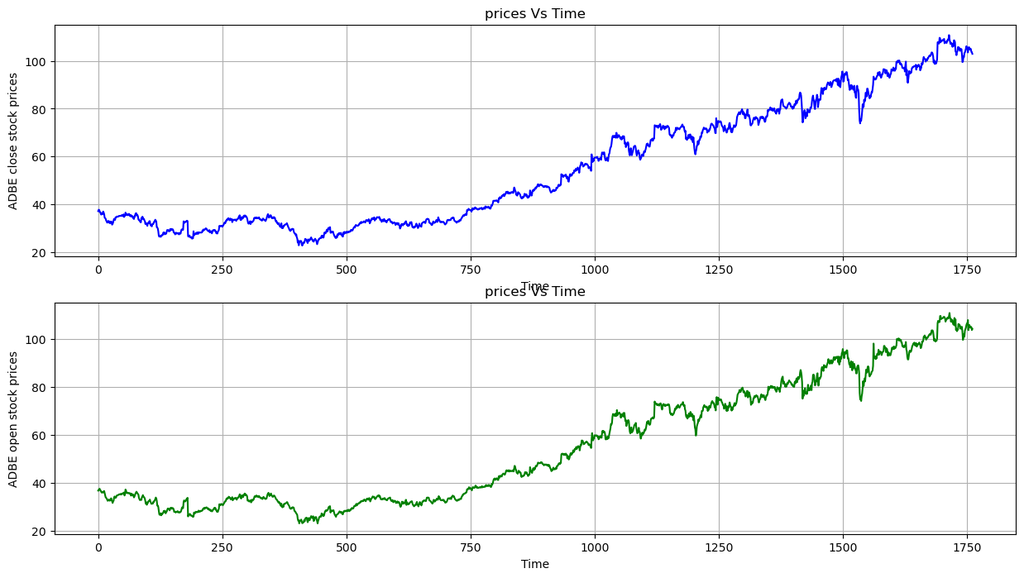

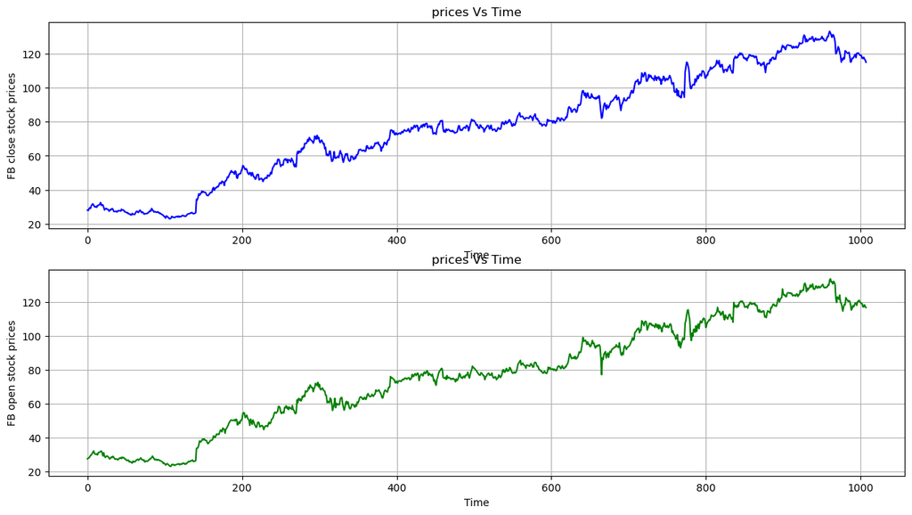

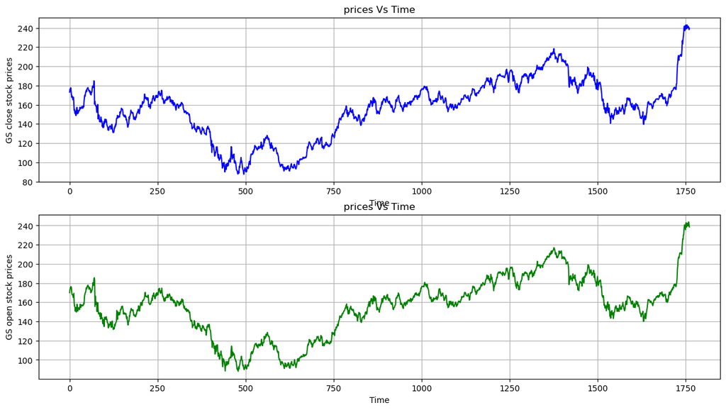

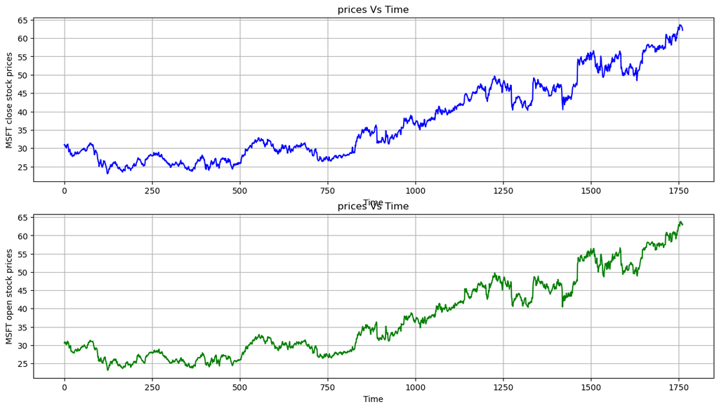

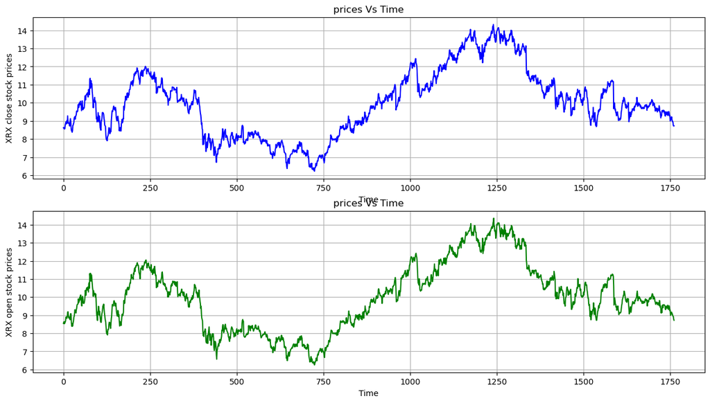

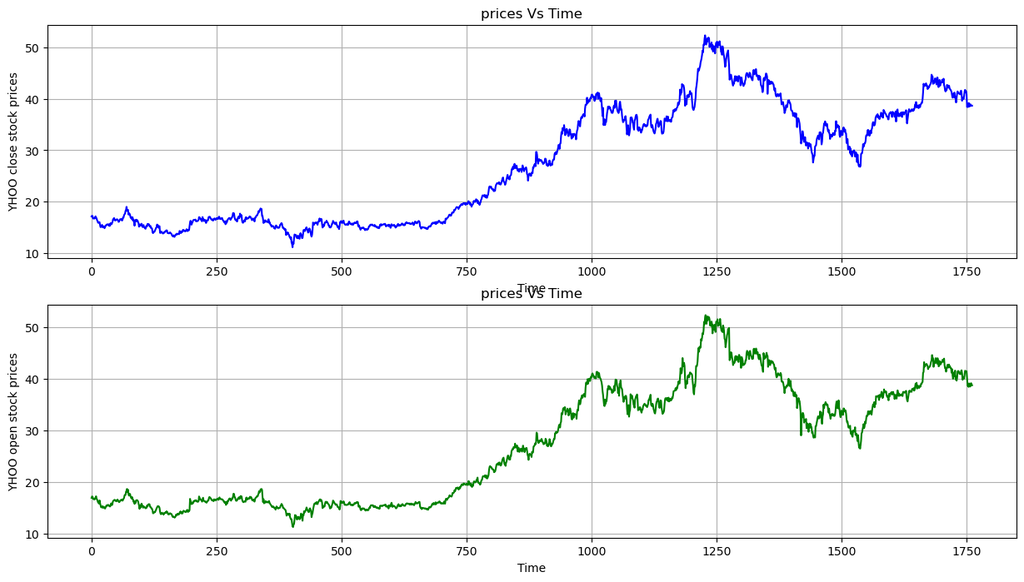

```python
# Calling the graphs through the function
for i in comp_plot:
    plotter(i)
```

Plot Summary

Adobe report

As we can see, that close and open started around 38 points and shows an increasing growth with time. The open and close graph closes at a very high position (around 105) compared to the start.

Facebook report

As the graph shows, open and close started around 30 points. And from there, it shows a bit downfall time 150. But then it shows a massive uprise and ends at the120 points for both open and close.

Goldman Sachs

As we see in graphs of open and close stocks, we see that Goldman has taken many up and downs almost the whole journey. It starts from high points than others around 175 points and faced major downfall but at last, it reached higher to 240 points.

Microsoft

As the graphs explain open and close stock for Microsoft started from 30 points. And from there they show total elevation to 65 points. It is a great option for investment

Xerox

As the graphs suggest for Xerox, it started from very low points of 9 and from there it struggled to progress. There was a major fall after some time and in the end, the stock prices are still nearly the same.

Yahoo

As we see in the graphs, Yahoo prices remained the same for some time. But then they show effective progress. And at the end, they go to around 40 points.

```python
# Extract closing stock of one company, here YHOO
stocks= np.array (df[df.symbol.isin (['YHOO'])].close)
print(stocks)
```

```
[17.1      17.23     17.17     ... 38.73     38.639999 38.669998]
```

```python
# Display Shape
display (stocks.shape)
```

```
(1762,)
```

```python
# Convert stock to 2D array
stocks = stocks.reshape(len(stocks) , 1)
print (stocks.shape)
print(stocks)
```

```
(1762, 1)
[[17.1     ]
 [17.23    ]
 [17.17    ]
 ...
 [38.73    ]
 [38.639999]
 [38.669998]]
```

# Min Max Scaler

Feature Scaling: MinMaxScaler from sklearn.preprocessing is used to scale the 'close' stock prices between 0 and 1. This scaling ensures that all features are on a similar scale, which can improve the performance of machine learning models.

X_scaled = (X - X_min) / (X_max - X_min)

```python
# Feature scaling the vector for better model performance
from sklearn.preprocessing import MinMaxScaler
#scaling features between 0 and 1
scaler = MinMaxScaler(feature_range=(0, 1))
stocks = scaler.fit_transform(stocks)
display (stocks)
```

```
array([[0.14559109],
       [0.14874031],
       [0.14728683],
       ...,
       [0.66957366],
       [0.6673934 ],
       [0.66812012]])
```

# Train Test Split (80 % Training and 20 % Test Data)

The dataset is split into training and testing sets using a ratio of 80:20. This allows the model to be trained on a portion of the data and evaluated on unseen data to assess its performance.

```python
# Total Number of Records
print (stocks.shape)
```

```
(1762, 1)
```

```python
# 80 % Training record count
train = int(len(stocks) * 0.80)
print (train)
```

```
1409
```

```python
# 20 % record count  (Total – 80%)
test = len(stocks) - train
print (test)
```

```
353
```

# Training Data

```python
#divinding the values of stocks data to train from 0 to 1409 i.e 80% data
train = stocks[0:train]
display (train.shape)
print(train)
```

```
(1409, 1)
```

```
[[0.14559109]
 [0.14874031]
 [0.14728683]
 ...
 [0.63372095]
 [0.61458332]
 [0.61967051]]
```

# Test Data

```python
#divinding the values of stocks data to test from train ending to stock data ending i.e rest 20% data
test = stocks[len(train) : ]
display(test.shape)
display (test)
```

```
(353, 1)
```

```
array([[0.63129851],
       [0.60416666],
       [0.56686053],
       [0.6017442 ],
       [0.60925394],
       [0.60586237],
       [0.59593022],
       [0.58381782],
       [0.55741276],
       [0.52906978],
       [0.48982557],
       [0.50024226],
       [0.51913761],
       [0.54748061],
       [0.53415697],
       [0.51235471],
       [0.49685079],
       [0.500969  ],
       [0.51962213],
       [0.49636629],
       [0.47989342],
       [0.4949128 ],
       [0.48594962],
       [0.49273257],
       [0.46584303],
       [0.48328492],
       [0.49200583],
       [0.48062017],
       [0.47601745],
       [0.48643412],
       [0.46778102],
       [0.45179265],
       [0.44210272],
       [0.43701549],
       [0.39995156],
       [0.41593993],
       [0.43168606],
       [0.43168606],
       [0.47529068],
       [0.47868218],
```

[output cut: 298 more lines]

```
       [0.74297478],
       [0.73183139],
       [0.73594965],
       [0.72238374],
       [0.66182172],
       [0.66666671],
       [0.66206392],
       [0.67999033],
       [0.67974813],
       [0.66400195],
       [0.66787792],
       [0.67417632],
       [0.66957366],
       [0.6673934 ],
       [0.66812012]])
```

# Data Preparation

Process Data Function: The process_data() function is defined to prepare the dataset for time series forecasting. It takes the data and the number of features (previous time steps) as inputs and creates input-output pairs for training the model.

```python
#creating function to create trainX,testX and target(trainY, testY)
def process_data(data , n_features):
    dataX, dataY = [], [] # creating data for dataset and dividing inta X,Y
    for i in range(len(data)-n_features):
        # taking i range from total size- 3
        a = data[i:(i+n_features), 0]
        # Here a is value of data from i to i+ n_features, ie two values and put it in dataX
        dataX.append(a) #putting a in dataX
        #here dataY takes the value of data of i + n_features
        # putting i+ n_features in  dataY
        dataY.append(data[i + n_features, 0])
    # returning dataX and dataY in array
    return np.array(dataX), np.array(dataY)
```

Preparing Training, Testing, and Full Data: The process_data() function is called to prepare the training, testing, and full datasets. For each dataset, input sequences of two previous time steps are used to predict the next time step's value.

Call the function to prepare training data

n_features: This is the number of previous period’s data required to do the current prediction. In this case, use two previous records data to predict the current value.

```python
n_features = 2
```

```python
# Here we create train X, Train Y and test X, Test Y data where trainX, testX has two value is each block
trainX, trainY = process_data(train, n_features)
print(trainX.shape , trainY.shape)
```

```
(1407, 2) (1407,)
```

Call the function to prepare test data

```python
n_features = 2
```

```python
testX, testY = process_data(test, n_features)
print (testX.shape , testY.shape)
```

```
(351, 2) (351,)
```

Call the function to prepare full data

```python
n_features = 2
```

```python
stocksX, stocksY = process_data(stocks, n_features)
print (stocksX.shape , stocksY.shape)
```

```
(1760, 2) (1760,)
```

```python
# Display the First 10 Records from Train X
display (trainX[:10])
```

```
array([[0.14559109, 0.14874031],
       [0.14874031, 0.14728683],
       [0.14728683, 0.13590119],
       [0.13590119, 0.13590119],
       [0.13590119, 0.13687016],
       [0.13687016, 0.13541667],
       [0.13541667, 0.14074613],
       [0.14074613, 0.14607561],
       [0.14607561, 0.13880814],
       [0.13880814, 0.13711241]])
```

```python
# Display the First 10 Records from TrainY
display (trainY[:10])
```

```
array([0.14728683, 0.13590119, 0.13590119, 0.13687016, 0.13541667,
       0.14074613, 0.14607561, 0.13880814, 0.13711241, 0.1281492 ])
```

```python
# reshaping trainX and testX to use in deep learning model
trainX = trainX.reshape(trainX.shape[0] , 1 ,trainX.shape[1])
display (trainX.shape)
```

```
(1407, 1, 2)
```

```python
# Reshape to 3D array test X
testX = testX.reshape(testX.shape[0] , 1 ,testX.shape[1])
display (testX.shape)
```

```
(351, 1, 2)
```

```python
# Reshape to 3D array  full data set
stocksX= stocksX.reshape(stocksX.shape[0] , 1 ,stocksX.shape[1])
display (stocksX.shape)
```

```
(1760, 1, 2)
```

# Model Building

```python
!pip install tensorflow
```

```python
# helps us do mathematical operations
import math
# for setting layers one by one neural layer in model
from keras.models import Sequential
# types of layers
from keras.layers import Dense , BatchNormalization , Dropout , Activation
# types of RNN
from keras.layers import LSTM , GRU
#It puts the data in between given range to set data before putting layer
from sklearn.preprocessing import MinMaxScaler
# In this method the errors in column is squared and then mean is found
from sklearn.metrics import mean_squared_error
# Optimizers used
from keras.optimizers import Adam , SGD , RMSprop
```

```
WARNING:tensorflow:From C:\Users\DELL\anaconda3\Lib\site-packages\keras\src\losses.py:2976: The name tf.losses.sparse_softmax_cross_entropy is deprecated. Please use tf.compat.v1.losses.sparse_softmax_cross_entropy instead.
```

keras

Keras contains numerous implementations of commonly used neural-network building blocks such as layers, objectives, activation functions, optimizers, and a host of tools to make working with image and text data easier to simplify the coding necessary for writing deep neural network code.

RNN

recurrent neural network processes sequences — whether daily stock prices, sentences, or sensor measurements — one element at a time while retaining a memory (called a state) of what has come previously in the sequence.Recurrent means the output at the current time step becomes the input to the next time step. At each element of the sequence, the model considers not just the current input, but what it remembers about the preceding elements.

Optimizers

Optimization algorithms helps us to minimize (or maximize) an Objective function (another name for Error function) E(x) which is simply a mathematical function dependent on the Model’s internal learnable parameters which are used in computing the target values(Y) from the set of predictors(X) used in the model.

# Model Optimization

Learning Rate Reduction: Learning rate reduction is implemented using ReduceLROnPlateau from Keras callbacks. This callback reduces the learning rate when the validation loss stops improving, allowing the model to converge faster and potentially reach a better solution.

```python
#Checkpointing the model when required and using other call-backs.
filepath="stock_weights1.hdf5"
from keras.callbacks import ReduceLROnPlateau , ModelCheckpoint
# ReduceLROnPlateau- This reduce the learning rate when the matrix stop improving or  too close to reduce overfitting
lr_reduce = ReduceLROnPlateau(monitor='val_loss', factor=0.1, epsilon=0.0001, patience=1, verbose=1)
#This check point will stop processing, if the model is not improving.
checkpoint = ModelCheckpoint(filepath, monitor='val_loss', verbose=1, save_best_only=True, mode='max')
```

```
WARNING:tensorflow:`epsilon` argument is deprecated and will be removed, use `min_delta` instead.
```

Callbacks

A callback is a set of functions to be applied at given stages of the training procedure. You can use callbacks to get a view on internal states and statistics of the model during training. You can pass a list of callbacks (as the keyword argument callbacks) to the .fit() method of the Sequential or Model classes. The relevant methods of the callbacks will then be called at each stage of the training.

ReduceLROnPlateau

Reduce learning rate when a metric has stopped improving.Models often benefit from reducing the learning rate by a factor of 2-10 once learning stagnates. This callback monitors a quantity and if no improvement is seen for a 'patience' number of epochs, the learning rate is reduced.

ModelCheckpoint

Save the model after every epoch.filepath can contain named formatting options, which will be filled with the values of epoch and keys in logs (passed in on_epoch_end).

Create the model – Fully connected Layer

Creating the Model: Keras Sequential API is used to create the model architecture. Sequential models allow stacking layers one after the other, making it easy to define feedforward or recurrent neural networks.

Layers in the Model: The model consists of GRU and LSTM layers for sequence modeling, dropout layers for regularization to prevent overfitting, and dense layers for mapping features to the output.

LSTM Model Architecture:

Concept: Long Short-Term Memory (LSTM) is a type of recurrent neural network (RNN) architecture designed for learning long-term dependencies.

Working: LSTM units have gates controlling information flow: input gate, forget gate, output gate, and cell state.

GRU Model Layer:

Concept: Gated Recurrent Unit (GRU) is another type of RNN architecture that simplifies the LSTM by merging the forget and input gates into a single update gate.

Working: GRU units have reset and update gates controlling information flow.

```python
# creating model for training data using sequential to give series wise output between layers
model = Sequential()
# GRU or Gated Recurrent Unit used for matrix manipulation within Recurrent layer
#This is the input Layer
model.add(GRU(256 , input_shape = (1 , n_features) , return_sequences=True))
#dropout is used to remove overfitting data on each layer of neural network
model.add(Dropout(0.4))
#Long Short Term Memory is a type of RNN specially used for time series problems
model.add(LSTM(256))
#dropout is used to remove overfitting data on each layer of neural network
model.add(Dropout(0.4))
#Dense layer are fully connected neural networks
model.add(Dense(64 ,  activation = 'relu'))
#This is the output Layer, Output is only one neuron
model.add(Dense(1))
#for getting the details of our models
print(model.summary())
```

```
WARNING:tensorflow:From C:\Users\DELL\anaconda3\Lib\site-packages\keras\src\backend.py:873: The name tf.get_default_graph is deprecated. Please use tf.compat.v1.get_default_graph instead.

Model: "sequential"
_________________________________________________________________
 Layer (type)                Output Shape              Param #
=================================================================
 gru (GRU)                   (None, 1, 256)            199680

 dropout (Dropout)           (None, 1, 256)            0

 lstm (LSTM)                 (None, 256)               525312

 dropout_1 (Dropout)         (None, 256)               0

 dense (Dense)               (None, 64)                16448

 dense_1 (Dense)             (None, 1)                 65

=================================================================
Total params: 741505 (2.83 MB)
Trainable params: 741505 (2.83 MB)
Non-trainable params: 0 (0.00 Byte)
_________________________________________________________________
None
```

Model Compilation: The model is compiled with the appropriate loss function ('mean_squared_error'), optimizer (Adam), and metrics ('mean_squared_error'). The loss function measures how well the model is performing, the optimizer updates the model parameters to minimize the loss, and the metrics provide additional evaluation criteria.

Mean Squared Error (MSE) is commonly used as the loss function for regression tasks.

MSE = 1/n ∑ (y - y')^2

where y is the true value, y' is the predicted value and n is the number of samples.

```python
# Selecting the loss measurement metrics and optimizer for our model, to find out mean square error
model.compile(loss='mean_squared_error', optimizer=Adam(learning_rate = 0.0005) , metrics = ['mean_squared_error'])
```

# Model Training

```python
# fitting the data i.e training the trainX, to relate to trainY
# epochs is the times each data in send to fit
# batch size is the size of information send at a time
# validation_data is the validation or data used for testing
history = model.fit(trainX, trainY, epochs=100 , batch_size = 128 ,
          callbacks = [checkpoint , lr_reduce] , validation_data = (testX,testY))
```

```
WARNING:tensorflow:From C:\Users\DELL\anaconda3\Lib\site-packages\keras\src\utils\tf_utils.py:492: The name tf.ragged.RaggedTensorValue is deprecated. Please use tf.compat.v1.ragged.RaggedTensorValue instead.

WARNING:tensorflow:From C:\Users\DELL\anaconda3\Lib\site-packages\keras\src\engine\base_layer_utils.py:384: The name tf.executing_eagerly_outside_functions is deprecated. Please use tf.compat.v1.executing_eagerly_outside_functions instead.

Epoch 1: val_loss improved from -inf to 0.20430, saving model to stock_weights1.hdf5
Epoch 2: val_loss did not improve from 0.20430
Epoch 3: val_loss did not improve from 0.20430
Epoch 4: val_loss did not improve from 0.20430

Epoch 4: ReduceLROnPlateau reducing learning rate to 5.0000002374872565e-05.
Epoch 5: val_loss did not improve from 0.20430

Epoch 5: ReduceLROnPlateau reducing learning rate to 5.000000237487257e-06.
Epoch 6: val_loss did not improve from 0.20430

Epoch 6: ReduceLROnPlateau reducing learning rate to 5.000000328436726e-07.
Epoch 7: val_loss did not improve from 0.20430

Epoch 7: ReduceLROnPlateau reducing learning rate to 5.000000555810402e-08.
Epoch 8: val_loss did not improve from 0.20430

Epoch 8: ReduceLROnPlateau reducing learning rate to 5.000000413701855e-09.
Epoch 9: val_loss did not improve from 0.20430

Epoch 9: ReduceLROnPlateau reducing learning rate to 5.000000413701855e-10.
Epoch 10: val_loss did not improve from 0.20430

Epoch 10: ReduceLROnPlateau reducing learning rate to 5.000000413701855e-11.
Epoch 11: val_loss did not improve from 0.20430

Epoch 11: ReduceLROnPlateau reducing learning rate to 5.000000413701855e-12.
Epoch 12: val_loss did not improve from 0.20430

Epoch 12: ReduceLROnPlateau reducing learning rate to 5.000000413701855e-13.
Epoch 13: val_loss did not improve from 0.20430

Epoch 13: ReduceLROnPlateau reducing learning rate to 5.0000005221220725e-14.
Epoch 14: val_loss did not improve from 0.20430

Epoch 14: ReduceLROnPlateau reducing learning rate to 5.000000589884709e-15.
```

[output cut: 133 more lines]

```
Epoch 86: val_loss did not improve from 0.20430
Epoch 87: val_loss did not improve from 0.20430
Epoch 88: val_loss did not improve from 0.20430
Epoch 89: val_loss did not improve from 0.20430
Epoch 90: val_loss did not improve from 0.20430
Epoch 91: val_loss did not improve from 0.20430
Epoch 92: val_loss did not improve from 0.20430
Epoch 93: val_loss did not improve from 0.20430
Epoch 94: val_loss did not improve from 0.20430
Epoch 95: val_loss did not improve from 0.20430
Epoch 96: val_loss did not improve from 0.20430
Epoch 97: val_loss did not improve from 0.20430
Epoch 98: val_loss did not improve from 0.20430
Epoch 99: val_loss did not improve from 0.20430
Epoch 100: val_loss did not improve from 0.20430
```

# Model Prediction and Evaluation

Predictions: The trained model is used to make predictions on the test data.

Inverse Transform: The scaled predictions are inverse-transformed to obtain the original values.

Accuracy Metrics: The R-squared score is calculated to evaluate the model's performance. R-squared measures the proportion of variance in the dependent variable (actual stock prices) that is predictable from the independent variable (predicted stock prices).

```python
# Predict the value for testX, display top 10 records
test_pred = model.predict(testX)
display (test_pred [:10])
```

```
array([[0.52794737],
       [0.50489855],
       [0.5025403 ],
       [0.51838547],
       [0.5200985 ],
       [0.5154234 ],
       [0.5075204 ],
       [0.49395934],
       [0.47437766],
       [0.4504952 ]], dtype=float32)
```

```python
# Inverse Transform the data – Convert the data to Original form
test_pred = scaler.inverse_transform(test_pred)
display (test_pred [:10])
```

```
array([[32.883667],
       [31.93221 ],
       [31.834862],
       [32.488953],
       [32.559666],
       [32.366676],
       [32.04044 ],
       [31.480642],
       [30.67231 ],
       [29.686443]], dtype=float32)
```

```python
# Reshape and Display Original Data
testY = testY.reshape(testY.shape[0] , 1)
testY
```

```
array([[0.56686053],
       [0.6017442 ],
       [0.60925394],
       [0.60586237],
       [0.59593022],
       [0.58381782],
       [0.55741276],
       [0.52906978],
       [0.48982557],
       [0.50024226],
       [0.51913761],
       [0.54748061],
       [0.53415697],
       [0.51235471],
       [0.49685079],
       [0.500969  ],
       [0.51962213],
       [0.49636629],
       [0.47989342],
       [0.4949128 ],
       [0.48594962],
       [0.49273257],
       [0.46584303],
       [0.48328492],
       [0.49200583],
       [0.48062017],
       [0.47601745],
       [0.48643412],
       [0.46778102],
       [0.45179265],
       [0.44210272],
       [0.43701549],
       [0.39995156],
       [0.41593993],
       [0.43168606],
       [0.43168606],
       [0.47529068],
       [0.47868218],
       [0.48134689],
       [0.50339151],
```

[output cut: 296 more lines]

```
       [0.74297478],
       [0.73183139],
       [0.73594965],
       [0.72238374],
       [0.66182172],
       [0.66666671],
       [0.66206392],
       [0.67999033],
       [0.67974813],
       [0.66400195],
       [0.66787792],
       [0.67417632],
       [0.66957366],
       [0.6673934 ],
       [0.66812012]])
```

```python
#Converting reshaped list in 1D array so that it will be efficient in plotting
testY = scaler.inverse_transform(testY)
# taking testY from 1 to 10
display (testY[:10])
```

```
array([[34.490002],
       [35.93    ],
       [36.240002],
       [36.099998],
       [35.689999],
       [35.189999],
       [34.099998],
       [32.93    ],
       [31.309999],
       [31.74    ]])
```

R-squared error = 1 - (∑(y - y')^2) / (∑(y - y_mean)^2)

```python
# Display the accuracy
from sklearn.metrics import r2_score
r2_score(testY,test_pred)
```

```
0.2211456762927414
```

Plotting Results: Matplotlib is used to visualize the actual vs. predicted stock prices. The predictions are plotted against the true values to visually assess the model's performance.

Graphical Representation: Graphs are plotted to show the accuracy of the model on both the training and testing datasets. These graphs help in understanding how well the model captures the patterns in the data and whether it overfits or underfits.

# Plot the Graph Actual and Predicted Data

```
Red - Predicted Stock Prices  ,  Blue - Actual Stock Prices
```

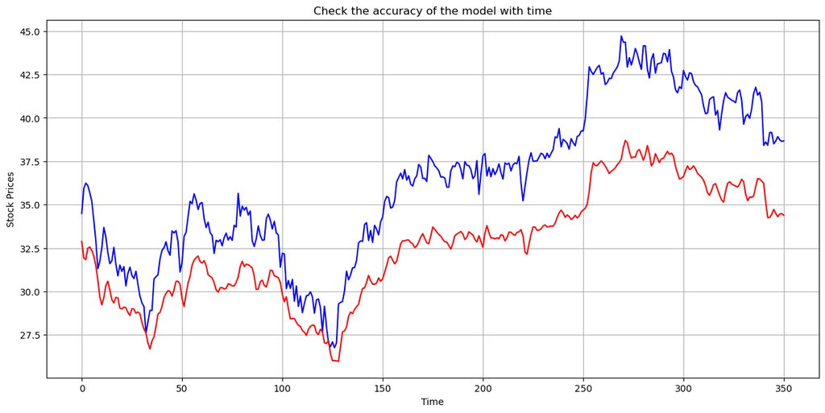

```python
# Ploting the graph of stock prices with time
print("Red - Predicted Stock Prices  ,  Blue - Actual Stock Prices")
plt.rcParams["figure.figsize"] = (15,7)
# testY is the blue line
plt.plot(testY , 'b')
# pred is the red line
plt.plot(test_pred , 'r')
# Setting x axis as time
plt.xlabel('Time')
# Setting y axis as stock prices
plt.ylabel('Stock Prices')
# setting title
plt.title('Check the accuracy of the model with time')
# enabling grids in graph
plt.grid(True)
# it call the graph with labels, titles, lines
plt.show()
```

```python
# Prediction Training Data and Check Accuracy
train_pred = model.predict(trainX)
train_pred = scaler.inverse_transform(train_pred)
trainY = trainY.reshape(trainY.shape[0] , 1)
trainY = scaler.inverse_transform(trainY)
print ('Display Accuracy Training Data')
display (r2_score(trainY,train_pred))
```

```
Display Accuracy Training Data
```

```
0.9084369614647355
```

# Plot the Graph

```
Red - Predicted Stock Prices  ,  Blue - Actual Stock Prices
```

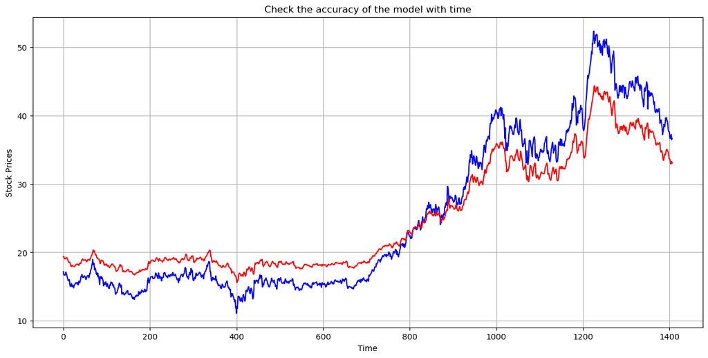

```python
# Ploting the graph of stock prices with time - Training Data
print("Red - Predicted Stock Prices  ,  Blue - Actual Stock Prices")
plt.rcParams["figure.figsize"] = (15,7)
plt.plot(trainY  , 'b')
plt.plot(train_pred, 'r')
plt.xlabel('Time')
plt.ylabel('Stock Prices')
plt.title('Check the accuracy of the model with time')
plt.grid(True)
plt.show()
```

Full Data Predictions: Finally, the model is used to predict stock prices on the full dataset.

Plotting Full Data Results: The actual and predicted stock prices on the full dataset are plotted to visualize the overall performance of the model.

# Prediction Full Data

```python
stocks_pred = model.predict(stocksX)
stocks_pred = scaler.inverse_transform(stocks_pred)
stocksY = stocksY.reshape(stocksY.shape[0] , 1)
stocksY = scaler.inverse_transform(stocksY)
print ('Display Accuracy Training Data')
display (r2_score(stocksY,stocks_pred))
```

```
Display Accuracy Training Data
```

```
0.9021724588108246
```

# Plot the Graph

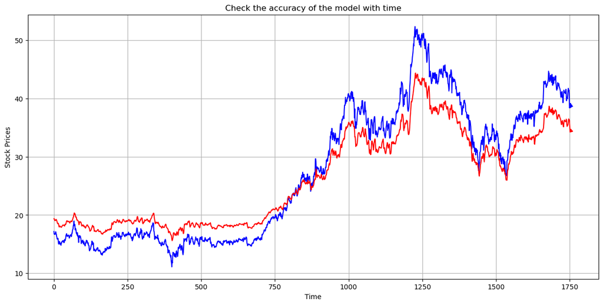

```python
plt.rcParams["figure.figsize"] = (15,7)
plt.plot(stocksY  , 'b')
plt.plot(stocks_pred, 'r')
plt.xlabel('Time')
plt.ylabel('Stock Prices')
plt.title('Check the accuracy of the model with time')
plt.grid(True)
plt.show()
```

# Concat original and prediction data

Concatenating Original and Predicted Data: The original dataset is concatenated with the predicted values to create a new DataFrame (results) that contains both the actual and predicted stock prices.

Adjusting Index: The index of the results DataFrame is adjusted to start from 0 to match the new concatenated data.

Exporting to Excel: The results DataFrame is exported to an Excel file named "results.xlsx" for further analysis or sharing with stakeholders.

```python
# Extract the data related to company - YHOO
results= df[df.symbol.isin (['YHOO'])]
# Update the data frame starting with 2nd records , since first prediction is for 2nd record
results= results [2:]
# Reset the index 0, 1,2 etc
results = results.reset_index(drop=True)
# Convert Predicted Value to Data Frame
df_stocks_pred= pd.DataFrame(stocks_pred, columns = ['Close_Prediction'])
# Concat Original and prediction data
results= pd.concat([results,df_stocks_pred],axis =1)
results.to_excel('results.xlsx')
display(results)
```

|  | date | symbol | open | close | low | high | volume | Close_Prediction |
| --- | --- | --- | --- | --- | --- | --- | --- | --- |
| 0 | 2010-01-06 | YHOO | 17.170000 | 17.170000 | 17.070000 | 17.299999 | 16422000.0 | 19.350552 |
| 1 | 2010-01-07 | YHOO | 16.809999 | 16.700001 | 16.570000 | 16.900000 | 31816300.0 | 19.377317 |
| 2 | 2010-01-08 | YHOO | 16.680000 | 16.700001 | 16.620001 | 16.760000 | 15470000.0 | 19.208509 |
| 3 | 2010-01-11 | YHOO | 16.770000 | 16.740000 | 16.480000 | 16.830000 | 16181900.0 | 19.043802 |
| 4 | 2010-01-12 | YHOO | 16.650000 | 16.680000 | 16.600000 | 16.860001 | 15672400.0 | 19.056355 |
| ... | ... | ... | ... | ... | ... | ... | ... | ... |
| 1755 | 2016-12-23 | YHOO | 38.459999 | 38.660000 | 38.369999 | 38.810001 | 3840100.0 | 34.497993 |
| 1756 | 2016-12-27 | YHOO | 38.590000 | 38.919998 | 38.500000 | 39.070000 | 4240300.0 | 34.302288 |
| 1757 | 2016-12-28 | YHOO | 39.119999 | 38.730000 | 38.709999 | 39.220001 | 4393500.0 | 34.453308 |
| 1758 | 2016-12-29 | YHOO | 38.759998 | 38.639999 | 38.480000 | 38.930000 | 4170200.0 | 34.488312 |
| 1759 | 2016-12-30 | YHOO | 38.720001 | 38.669998 | 38.430000 | 39.000000 | 6431600.0 | 34.384090 |

1760 rows × 8 columns